# MLR Regression Lab

# Multivariate Regression

We have now seen that we can extend our linear model to include more than one predictor or independent variables. For example, in one of our studies we consider the growth of odontoblasts in guinea pigs. In this study, there were two separate variables of interest: the dose of vitamin C delivered and the route of administration (either orange juice or ascorbic acid). The linear model constructed looked like this:

```r
library(ggplot2)
library(dplyr)
data(ToothGrowth)
lm(len ~ dose + supp, ToothGrowth) %>% summary()
```

```
##
## Call:
## lm(formula = len ~ dose + supp, data = ToothGrowth)
##
## Residuals:
##    Min     1Q Median     3Q    Max
## -6.600 -3.700  0.373  2.116  8.800
##
## Coefficients:
##             Estimate Std. Error t value Pr(>|t|)
## (Intercept)   9.2725     1.2824   7.231 1.31e-09 ***
## dose          9.7636     0.8768  11.135 6.31e-16 ***
## suppVC       -3.7000     1.0936  -3.383   0.0013 **
## ---
## Signif. codes:  0 '***' 0.001 '**' 0.01 '*' 0.05 '.' 0.1 ' ' 1
##
## Residual standard error: 4.236 on 57 degrees of freedom
## Multiple R-squared:  0.7038, Adjusted R-squared:  0.6934
## F-statistic: 67.72 on 2 and 57 DF,  p-value: 8.716e-16
```

Written as an equation, this has the form

$$\hat{y} = 9.27 + 9.764 \times (\text{dose}) - 3.7 \times \mathbb{1}_{VC}$$
That is, we find:

1. An intercept of 9.27 (note however that this is not a meaningful term as our predictor variable `dose` never takes on the value 0)
2. A slope of 9.76, indicating that every additional milligram of vitamin C resulted in 9.76 millimeter change in odontoblast length
3. A -3.7 associated with the indicator for ascorbic acid. As this is an indicator term, it effectively shifts the regression line vertically, according to the sign. Additionally, because this is an indicator for ascorbic acid, it tells us that orange juice has become the reference variable

A plot of this regression looks like this:

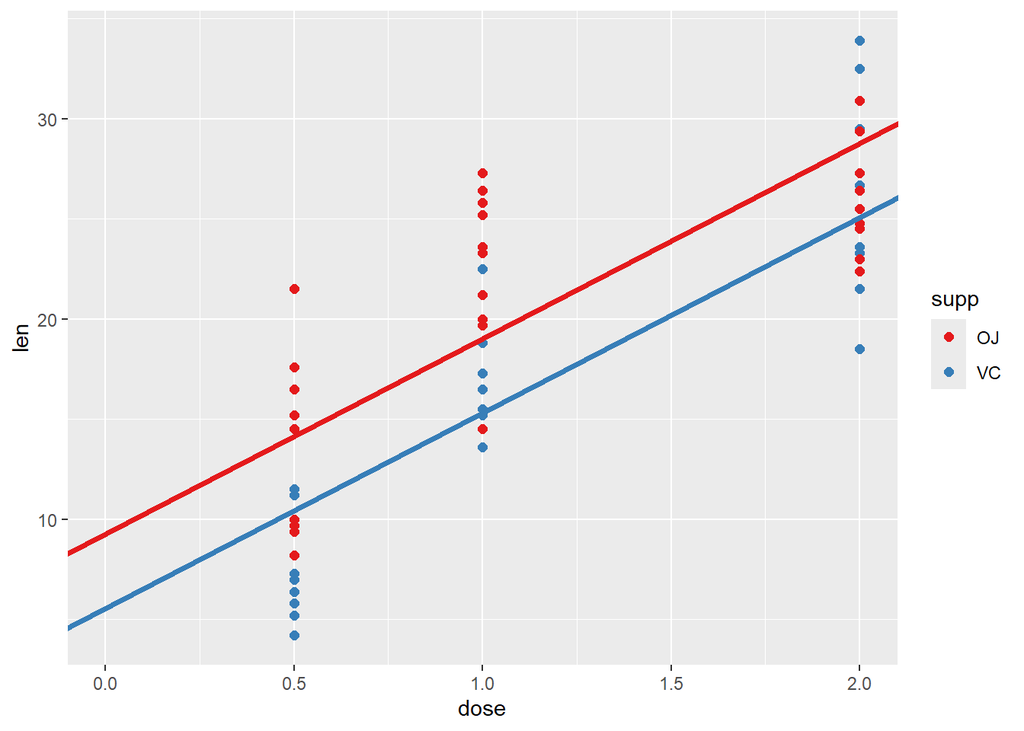

Looking at this, we see indeed that the intercept for the red line is about 9.2, with the intercept for ascorbic acid is shifted 3.7 lower. The slope for these two lines remains the same.

# College Data

For the following questions, our goal is to create a linear model to predict enrollment at primary undergraduate institutions in the United States.

```r
college_data <- read.csv("https://remiller1450.github.io/data/Colleges2019_Complete.csv")
```

### Question 1

Create a correlation heatmap and identify some of the variables that may have a linear relationship (positive or negative) with enrollment.

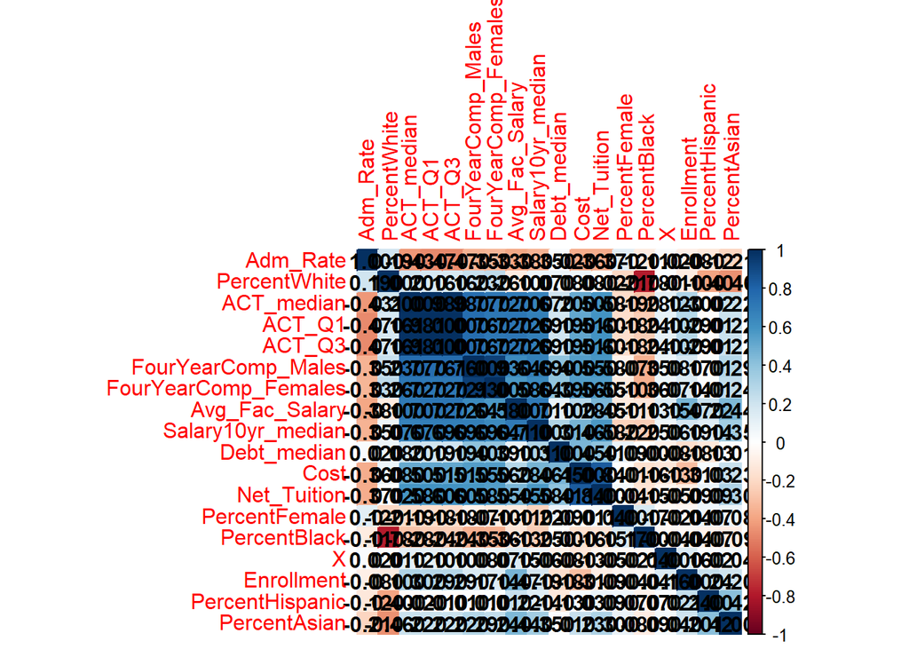

```r
colleges_quant_only = college_data %>% select(where(is.numeric))
library(corrplot)
## Store the correlation matrix
my_corr_matrix = cor(x = colleges_quant_only, method = "pearson", use = "complete.obs")
## Plot using corrplot, change colors if needed
corrplot(my_corr_matrix, method = "color", addCoef.col = "black", order="hclust")
```

### Question 2

- **Part A:** Create a linear model with Enrollment as our response variable and ACT_median and Private as our explanatory variables. Does there seem to be a linear relationship between the response and predictor variables?

```r
lm(Enrollment ~ ACT_median + Private, college_data) %>% summary()
```

```
##
## Call:
## lm(formula = Enrollment ~ ACT_median + Private, data = college_data)
##
## Residuals:
##    Min     1Q Median     3Q    Max
## -13197  -3309   -355   1600  43985
##
## Coefficients:
##                Estimate Std. Error t value Pr(>|t|)
## (Intercept)   -16565.59    1328.19  -12.47   <2e-16 ***
## ACT_median       808.32      54.66   14.79   <2e-16 ***
## PrivatePublic   9147.79     395.55   23.13   <2e-16 ***
## ---
## Signif. codes:  0 '***' 0.001 '**' 0.01 '*' 0.05 '.' 0.1 ' ' 1
##
## Residual standard error: 6408 on 1092 degrees of freedom
## Multiple R-squared:  0.3893, Adjusted R-squared:  0.3882
## F-statistic:   348 on 2 and 1092 DF,  p-value: < 2.2e-16
```

**Answer**: Yes, based on the F-statistic and p-value there does (would need to check the scatterplot to be sure).

- **Part B**: Using the summary information, explain how ACT_median and Private impact the predicted enrollment.

**Answer**: Larger ACT_median results in increased predictions for Enrollment. A college being Private results in a lower predicted enrollment.

- **Part C**: Using multiple $R^2$, explain how well this model fits.

**Answer**: The model fit is only OK-ish. We are explaining only about 40% of the variation in enrollment. Much of the variation is unaccounted for.

- **Part D**: Use a scatterplot to make sure Enrollment actually has a linear relationship with the predictors. Are there any issues? Regardless we will continue to practice in the following questions.

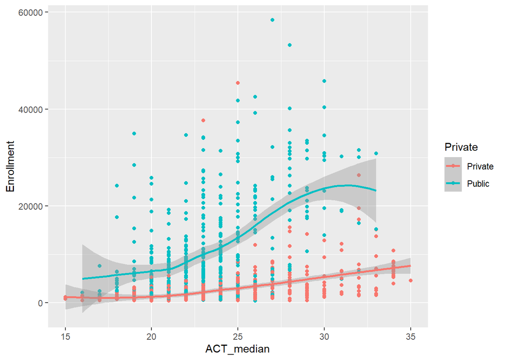

```r
college_data %>% ggplot(aes(x = ACT_median, y=Enrollment, color=Private)) + geom_point() + geom_smooth()
```

The relationship between ACT_median and Enrollment for public colleges may be non-linear.

### Question 3

We are now going to see if adding other variables gives us a better performing linear model.

- **Part A:** Create two scatter plots investigating the relationship between Enrollment and both Debt_median and Salary10yr_median. Which appears to be most correlated with Enrollment? Which do you think would be a better variable to add to the linear model in Question 2?

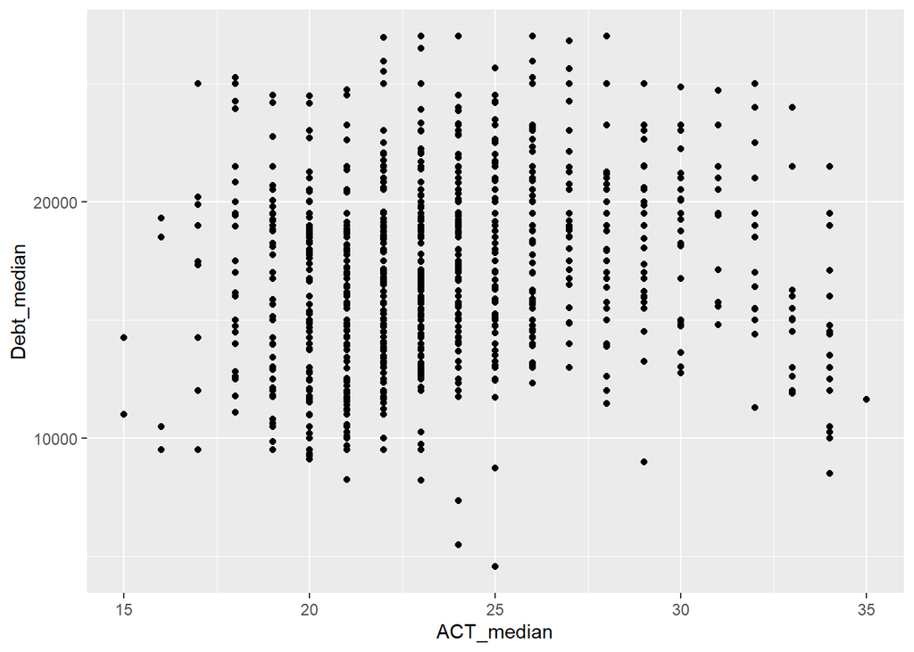

```r
college_data %>% ggplot(aes(x=ACT_median, y = Debt_median)) +
  geom_point()
```

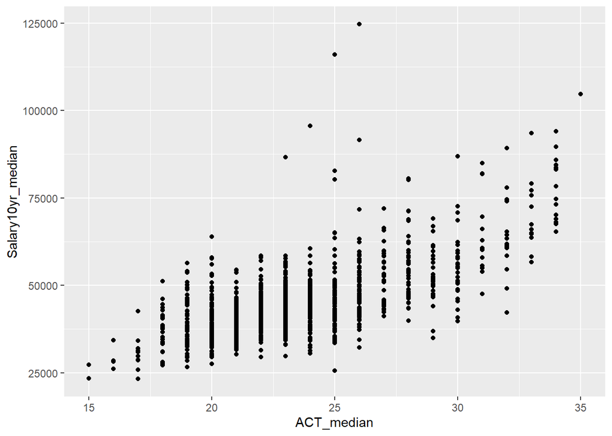

```r
college_data %>% ggplot(aes(x=ACT_median, y = Salary10yr_median)) +
  geom_point()
```

```r
# relationship between ACT_median and Salary10yr_median looks
# much stronger and also linear => should be better to add?
```

- **Part B:** Create two additional linear models for predicting Enrollment, one adding Debt_median to the model in Q2A, the other adding Salary10yr_median. Is what you found consistent with what you chose in Question 3 Part A? What metric(s) would you use in support of your choice.

```r
lm(Enrollment ~ ACT_median + Salary10yr_median + Private, college_data) %>% summary()
```

```
##
## Call:
## lm(formula = Enrollment ~ ACT_median + Salary10yr_median + Private,
##     data = college_data)
##
## Residuals:
##    Min     1Q Median     3Q    Max
## -13199  -3335   -390   1570  44107
##
## Coefficients:
##                     Estimate Std. Error t value Pr(>|t|)
## (Intercept)       -1.652e+04  1.330e+03 -12.419   <2e-16 ***
## ACT_median         7.705e+02  7.331e+01  10.510   <2e-16 ***
## Salary10yr_median  1.827e-02  2.362e-02   0.774    0.439
## PrivatePublic      9.168e+03  3.965e+02  23.123   <2e-16 ***
## ---
## Signif. codes:  0 '***' 0.001 '**' 0.01 '*' 0.05 '.' 0.1 ' ' 1
##
## Residual standard error: 6409 on 1091 degrees of freedom
## Multiple R-squared:  0.3896, Adjusted R-squared:  0.3879
## F-statistic: 232.1 on 3 and 1091 DF,  p-value: < 2.2e-16
```

```r
lm(Enrollment ~ ACT_median + Debt_median + Private, college_data) %>% summary()
```

```
##
## Call:
## lm(formula = Enrollment ~ ACT_median + Debt_median + Private,
##     data = college_data)
##
## Residuals:
##    Min     1Q Median     3Q    Max
## -13021  -3239   -393   1564  43696
##
## Coefficients:
##                 Estimate Std. Error t value Pr(>|t|)
## (Intercept)   -1.389e+04  1.510e+03  -9.199  < 2e-16 ***
## ACT_median     8.453e+02  5.528e+01  15.291  < 2e-16 ***
## Debt_median   -1.974e-01  5.395e-02  -3.658 0.000266 ***
## PrivatePublic  8.699e+03  4.120e+02  21.112  < 2e-16 ***
## ---
## Signif. codes:  0 '***' 0.001 '**' 0.01 '*' 0.05 '.' 0.1 ' ' 1
##
## Residual standard error: 6372 on 1091 degrees of freedom
## Multiple R-squared:  0.3967, Adjusted R-squared:  0.395
## F-statistic: 239.1 on 3 and 1091 DF,  p-value: < 2.2e-16
```

**Answer:** Adding either actually performs about the same judging by $R^2$, the F-stat, and p-value.

### Question 4

Find Grinnell in the college dataset. Make an enrollment prediction for Grinnell using the better regression model in Question 3. Interpret the residual. Did our regression model perform well for Grinnell?

```r
college_data[college_data$Name=="Grinnell College",]$ACT_median
```

```
## [1] 32
```

```r
college_data[college_data$Name=="Grinnell College",]$Debt_median
```

```
## [1] 15000
```

```r
model = lm(Enrollment ~ ACT_median + Debt_median + Private, college_data)

predict(model, newdata=college_data[college_data$Name=="Grinnell College",])
```

```
##      314
## 10198.94
```

```r
# could also have used values directly with the equation
```